# MixviR_Paper_Analyses

Mike Sovic

8/11/2022

```r
knitr::opts_chunk$set(message = FALSE,
                      warning = FALSE)
```

This document contains code associated with analyses in the paper describing *MixviR*. The code is generalized, so paths to files will need to be updated to replicate analyses.

The validation analyses involve two datasets - one with mixtures of SARS-CoV-2, and another with mixture samples from *M. tuberculosis*. Both datasets are available from NCBI’s short read archive (SRA). Fastq files were downloaded from SRA with the SRA Import app in Basespace.

# Primary Manuscript Analyses

## Alignment/Variant Calling

### SARS-CoV-2

Alignment and variant calling for the SARS-CoV-2 samples were performed with the DRAGEN Covid Lineage App v3.5.10 in Basespace using the primer bed file associated with Artic v4 primers and the callability and coverage thresholds to 1. Default settings were otherwise used. Resulting vcf files were obtained and used as input for *MixviR* analyses.

### M. tuberculosis

Alignment and variant calling for the *M. tuberculosis* samples were performed with the DRAGEN Somatic App v4.0.3 in Basespace. Alignments were performed against the reference H37Rv (genome build ASM19595v2) after cleaning reference chromosome names for compatibility with *MixviR*. Variant calling was performed by turning off filtering of multiallelic variants, setting –vc-enable-unequal-ntd-errors to false, and setting Somatic Hotspots to ‘None’. Resulting vcf files were obtained and used as input for *MixviR* analyses.

## Load R Packages

```r
library(MixviR)
library(tidyverse)
library(patchwork)
library(magrittr)
```

## Summarize Coverages For Each Dataset

Get estimates of coverage per position for each dataset.

### SARS-CoV-2

```r
#These values come from the Basespace report_metrics.json file generated as part of the DRAGEN Covid Lineages anlysis - they are median coverages.

sars_coverage <- data.frame("Sample" = c("SRR18962157", "SRR18962947", "SRR18961847", "SRR18961947", "SRR18939817", "SRR18936975", "SRR18962138"),
                            "Sample_coverage" = c(5070, 4699, 5195, 5047, 5225, 4845, 4688))

sars_coverage <- sars_coverage %>%
  pull(Sample_coverage) %>%
  mean()

sars_coverage
```

```
## [1] 4967
```

### M. tuberculosis

```r
#These values come from the Basespace report associated with the mapping performed as part of the DRAGEN Somatic analysis.

mtub_coverage <- data.frame("Sample" = c("ERR221660", "ERR221662", "ERR221663", "ERR221664", "ERR221665", "ERR221666"),
                            "mapped_bases" = c(973483800, 814497000, 843343500, 769179600, 697562200, 721993700))

mtub_genome_size <- 4411532

mtub_coverage <- mtub_coverage %>%
  mutate("Sample_coverage" = mapped_bases/mtub_genome_size) %>%
  pull(Sample_coverage) %>%
  mean()

mtub_coverage
```

```
## [1] 182.1008
```

The full datasets have relatively high depths overall, with coverages for the SARS-CoV-2 dataset ~5000x and the *M.tuberculosis* dataset in the range of ~150-200x.

## Prep Additional Files for MixviR Validation Analyses

### SARS-CoV-2

#### Mutation File

Mutation tables associated with SARS-CoV-2 lineages/variants were downloaded from outbreak.org on Feb 17, 2022 and combined into a “lineage.muts” file for *MixviR*. This file is available from https://github.com/mikesovic/MixviR/tree/main/mutation_files and also from https://raw.githubusercontent.com/mikesovic/MixviR/main/mixvir_paper/SarsCov2_lineage_muts.csv

### M. tuberculosis

#### Mutation File

Mutations associated with lineages designated “L1” and “L3” (corresponding to lineages EAI6-BGD1 and CAS1-Kili, respectively) were obtained from Table S3 of Merker et al (2020) to generate the “lineage.muts” file for *MixviR*. It is available from “https://raw.githubusercontent.com/mikesovic/MixviR/main/mixvir_paper/Mtub_lineage_muts.csv”.

#### Prep bed File

```bash
curl -L -o mtub.gff.gz https://ftp.ncbi.nlm.nih.gov/genomes/all/GCF/000/195/955/GCF_000195955.2_ASM19595v2/GCF_000195955.2_ASM19595v2_genomic.gff.gz
gunzip mtub.gff.gz

grep -v -E "^#" mtub.gff | \
awk 'BEGIN {OFS="\t"} $3=="gene" {print $1,$4,$5,$6,$7,$9}' | \
sed -E 's/(ID=.+Name=)(.+)(;experiment.+)/\2/' | \
sed -E 's/(ID=.+Name=)(.+)(;gbkey.+)/\2/' | \
awk 'BEGIN {OFS="\t"} {print $1,$2,$3,$6,$4,$5}' > mixvir_mtub.bed
```

#### Clean Up Reference Chromosome Names

```bash
sed -E 's/[[:space:]].*$//' mtub.fa > mtub_clean.fa
```

# MixviR Analyses

## Functions

```r
mut_count_plot <- function(dataset, coverage, fig.num){

  mut_count_total <- readr::read_csv(paste0("dragen_runs/", dataset, "/", coverage, "/estimated_proportions.csv")) %>%
    dplyr::select(Sample, Lineage, Num_Target_Muts) %>%
    dplyr::mutate("Class" = "Total")

  mut_count_observed <- readr::read_csv(paste0("dragen_runs/", dataset, "/", coverage, "/estimated_proportions.csv")) %>%
    dplyr::select(Sample, Lineage, Num_Target_Muts, Proportion_Present) %>%
    dplyr::mutate("Class" = "Observed",
                  "Num_Target_Muts" = Num_Target_Muts*Proportion_Present) %>%
    dplyr::select(Sample, Lineage, Num_Target_Muts, Class)

  mut_count_results <- dplyr::bind_rows(mut_count_total, mut_count_observed) %>%
    dplyr::mutate("Sample" = stringr::str_replace_all(Sample, "SRR18936975.hard-filtered.vcf.gz", "Mixture 1")) %>%
    dplyr::mutate("Sample" = stringr::str_replace_all(Sample, "SRR18939817.hard-filtered.vcf.gz", "Mixture 2")) %>%
    dplyr::mutate("Sample" = stringr::str_replace_all(Sample, "SRR18961947.hard-filtered.vcf.gz", "Mixture 3")) %>%
    dplyr::mutate("Sample" = stringr::str_replace_all(Sample, "SRR18961847.hard-filtered.vcf.gz", "Mixture 4")) %>%
    dplyr::mutate("Sample" = stringr::str_replace_all(Sample, "SRR18962157.hard-filtered.vcf.gz", "Mixture 5")) %>%
    dplyr::mutate("Sample" = stringr::str_replace_all(Sample, "SRR18962947.hard-filtered.vcf.gz", "Mixture 6")) %>%
    dplyr::mutate("Sample" = stringr::str_replace_all(Sample, "SRR18962138.hard-filtered.vcf.gz", "Mixture 7")) %>%
    dplyr::mutate("Lineage" = stringr::str_replace_all(Lineage, "Omicron_", "")) %>%
    dplyr::mutate("Class" = factor(Class, levels = c("Total", "Observed"))) %>%
    dplyr::mutate("Lineage" = stringr::str_replace_all(Lineage, "L1 \\(EAI\\)", "EAI")) %>%
    dplyr::mutate("Lineage" = stringr::str_replace_all(Lineage, "L3 \\(CAS\\)", "CAS")) %>%
    dplyr::mutate("Sample" = stringr::str_replace_all(Sample, ".hard-filtered.vcf.gz", ""))

  if (dataset == "SARS-CoV-2") {
    mut_count_results <- mut_count_results %>%
       dplyr::filter((Sample == "Mixture 1" & Lineage %in% c("Alpha", "BA.1")) |
                     (Sample == "Mixture 2" & Lineage %in% c("BA.2", "Delta")) |
                     (Sample == "Mixture 3" & Lineage %in% c("Alpha", "BA.2")) |
                     (Sample == "Mixture 4" & Lineage %in% c("Alpha", "Delta")) |
                     (Sample == "Mixture 5" & Lineage %in% c("Delta", "BA.1")) |
                     (Sample == "Mixture 6" & Lineage %in% c("Alpha", "BA.2", "Delta")) |
                     (Sample == "Mixture 7" & Lineage %in% c("Alpha", "BA.1", "BA.2", "Delta")))
  }

  if (dataset == "SARS-CoV-2") {
    mut_count_plot <- ggplot2::ggplot(mut_count_results, ggplot2::aes(x = Lineage, y = Num_Target_Muts, fill = Class)) +
                      ggplot2::geom_bar(stat = "identity", position = "dodge") +
                      ggplot2::scale_fill_brewer(palette = "Paired") +
                      ggplot2::facet_wrap(ggplot2::vars(Sample), scales = "free") +
                      ggplot2::theme(axis.title.x = ggplot2::element_blank()) +
                      ggplot2::labs(y = "Number Of Target Mutations",
                                    title = paste0("MixviR Validation: ", dataset, " Mixtures"),
                                    subtitle = "Lineage-Characteristic Mutations Detected") +
                      ggplot2::theme(legend.direction = "horizontal",
                                     legend.position = c(0.86, 0.08),
                                     legend.justification = c(1, 0),
                                     legend.key.size = ggplot2::unit(0.7, 'cm'),
                                     legend.title = ggplot2::element_blank(),
                                     legend.text = ggplot2::element_text(size = 7),
                                     strip.text = ggplot2::element_text(size = 9),
                                     axis.text = ggplot2::element_text(size = 7),
                                     title = ggplot2::element_text(size = 11),
                                     axis.title = ggplot2::element_text(size = 9))
  } else {

    mut_count_plot <- ggplot2::ggplot(mut_count_results, ggplot2::aes(x = Lineage, y = Num_Target_Muts, fill = Class)) +
                      ggplot2::geom_bar(stat = "identity", position = "dodge") +
                      ggplot2::scale_fill_brewer(palette = "Paired") +
                      ggplot2::facet_wrap(ggplot2::vars(Sample), scales = "free") +
                      ggplot2::theme(axis.title.x = ggplot2::element_blank()) +
                      #ggplot2::ggtitle("Target Mutations Identified From Mixtures of M. tuberculosis Lineages") +
                      ggplot2::labs(y = "Number Of Target Mutations",
                                    title = expression(paste("MixviR Validation: ", italic("M. tuberculosis"), " Mixtures")),
                                    subtitle = "Lineage-Characteristic Mutations Detected") +
                      ggplot2::theme(legend.title = ggplot2::element_blank(),
                                     legend.text = ggplot2::element_text(size = 7),
                                     strip.text = ggplot2::element_text(size = 9),
                                     axis.text = ggplot2::element_text(size = 7),
                                     title = ggplot2::element_text(size = 11),
                                    axis.title = ggplot2::element_text(size = 9)) +
                      scale_y_continuous(breaks = c(2,4,6,8,10), labels = c(2,4,6,8,10))

  }

ggplot2::ggsave(filename = paste0("dragen_runs/", dataset, "/", coverage, "/Figure_", fig.num, ".tiff"),
                plot = mut_count_plot,
                dpi = 300)

mut_count_plot
}


lin_prop_plot <- function(dataset, coverage, fig.num) {

 if (dataset == "SARS-CoV-2") {
  prop_expected <- readr::read_csv("https://raw.githubusercontent.com/mikesovic/MixviR/main/mixvir_paper/SarsCov2_expected_lineage_proportions.csv")
 } else {
  prop_expected <- readr::read_csv("https://raw.githubusercontent.com/mikesovic/MixviR/main/mixvir_paper/Mtub_expected_lineage_proportions.csv")
}

 prop_expected <- prop_expected %>%
   dplyr::rename("Sample Proportion" = "Scaled Proportion Mean")

 prop_observed <- readr::read_csv(paste0("dragen_runs/", dataset, "/", coverage, "/estimated_proportions.csv"))

 prop_observed <- prop_observed %>%
    dplyr::filter(Proportion_Present >= 0.5)

 prop_observed <- prop_observed %>%
    dplyr::rename("Sample Proportion" = "Mean_Freq") %>%
    dplyr::mutate("Type" = "MixviR Estimate") %>%
    dplyr::select(Sample, Lineage, Type, `Sample Proportion`) %>%
    dplyr::mutate("Sample" = stringr::str_replace_all(Sample, "SRR18936975.hard-filtered.vcf.gz", "Mixture 1")) %>%
    dplyr::mutate("Sample" = stringr::str_replace_all(Sample, "SRR18939817.hard-filtered.vcf.gz", "Mixture 2")) %>%
    dplyr::mutate("Sample" = stringr::str_replace_all(Sample, "SRR18961947.hard-filtered.vcf.gz", "Mixture 3")) %>%
    dplyr::mutate("Sample" = stringr::str_replace_all(Sample, "SRR18961847.hard-filtered.vcf.gz", "Mixture 4")) %>%
    dplyr::mutate("Sample" = stringr::str_replace_all(Sample, "SRR18962157.hard-filtered.vcf.gz", "Mixture 5")) %>%
    dplyr::mutate("Sample" = stringr::str_replace_all(Sample, "SRR18962947.hard-filtered.vcf.gz", "Mixture 6")) %>%
    dplyr::mutate("Sample" = stringr::str_replace_all(Sample, "SRR18962138.hard-filtered.vcf.gz", "Mixture 7")) %>%
    dplyr::mutate("Lineage" = stringr::str_replace_all(Lineage, "Omicron_", "")) %>%
    dplyr::mutate("Lineage" = stringr::str_replace_all(Lineage, "L1 \\(EAI\\)", "EAI")) %>%
    dplyr::mutate("Lineage" = stringr::str_replace_all(Lineage, "L3 \\(CAS\\)", "CAS")) %>%
    dplyr::mutate("Sample" = stringr::str_replace_all(Sample, ".hard-filtered.vcf.gz", ""))

 results_prop <- dplyr::bind_rows(prop_expected, prop_observed)

 if (dataset == "SARS-CoV-2") {
   lin_prop_plot <- ggplot2::ggplot(results_prop, ggplot2::aes(x = Type, y = `Sample Proportion`, fill = Lineage)) +
    ggplot2::geom_bar(stat = "identity", position = "stack") +
    ggplot2::scale_fill_brewer(palette = "Paired") +
    ggplot2::facet_wrap(ggplot2::vars(Sample)) +
    ggplot2::theme(axis.title.x = ggplot2::element_blank()) +
    ggplot2::labs(y = "Proportion In Sample",
                  title = "",
                  subtitle = "Estimates Of Lineage Proportions") +
    ggplot2::theme(legend.direction = "horizontal",
                   legend.position = c(0.98, 0.08),
                  legend.justification = c(1, 0),
                  legend.key.size = ggplot2::unit(0.7, 'cm'),
                  legend.title = ggplot2::element_blank(),
                  legend.text = ggplot2::element_text(size = 6),
                  strip.text = ggplot2::element_text(size = 9),
                  axis.text = ggplot2::element_text(size = 7),
                  title = ggplot2::element_text(size = 11),
                  axis.title = ggplot2::element_text(size = 9)) +
    ggplot2::scale_x_discrete(labels= c("Expected", "MixviR\nEstimate"))
 } else {
   lin_prop_plot <- ggplot2::ggplot(results_prop, ggplot2::aes(x = Type, y = `Sample Proportion`, fill = Lineage)) +
                          ggplot2::geom_bar(stat = "identity", position = "stack") +
                          ggplot2::scale_fill_brewer(palette = "Paired") +
                          ggplot2::facet_wrap(ggplot2::vars(Sample)) +
                          ggplot2::theme(axis.title.x = ggplot2::element_blank()) +
                          ggplot2::labs(y = "Proportion In Sample",
                                        title = "",
                                        subtitle = "Estimates Of Lineage Proportions") +
                          ggplot2::theme(legend.title = ggplot2::element_blank(),
                                         legend.text = ggplot2::element_text(size = 7),
                                         strip.text = ggplot2::element_text(size = 9),
                                         axis.text = ggplot2::element_text(size = 7),
                                         title = ggplot2::element_text(size = 11),
                                        axis.title = ggplot2::element_text(size = 9)) +
                          ggplot2::scale_x_discrete(labels= c("Expected", "MixviR\nEstimate"))

 }

 ggplot2::ggsave(filename = paste0("dragen_runs/", dataset, "/", coverage, "/Figure_", fig.num, ".tiff"),
                plot = lin_prop_plot,
                dpi = 300)

 lin_prop_plot
}
```

## SARS-CoV-2 - Full Dataset

### `call_mutations()`

```r
call_mutations(sample.dir = "dragen_runs/SARS-CoV-2/full/vcfs/",
                   reference = "Wuhan",
                   write.mut.table = TRUE,
                   outfile.name = "dragen_runs/SARS-CoV-2/full/covid_samp_mutations.tsv")
```

### `estimate_lineages()`

```r
estimate_lineages(read.muts.from = "dragen_runs/SARS-CoV-2/full/covid_samp_mutations.tsv",
                      lineage.muts = "https://raw.githubusercontent.com/mikesovic/MixviR/main/mutation_files/outbreak_20220217.csv",
                  outfile.name = "dragen_runs/SARS-CoV-2/full/estimated_proportions.csv")
```

### Mutation Counts Plot

```r
sars_mut_count_plot_full <- mut_count_plot(dataset = "SARS-CoV-2", coverage = "full", fig.num = "2A")
```

### Lineage Proportions Plot

```r
sars_lin_prop_plot_full <- lin_prop_plot(dataset = "SARS-CoV-2", coverage = "full", fig.num = "2B")
```

### Combine SARS-CoV-2 Plots (Fig 2)

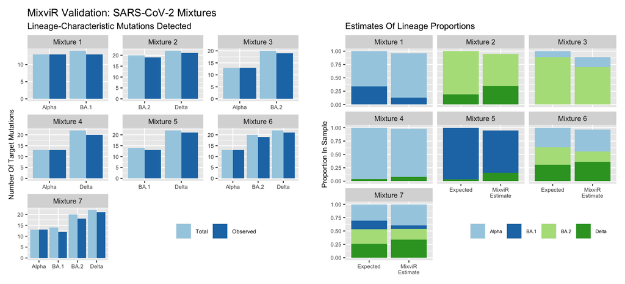

```r
sars_plot_full <- sars_mut_count_plot_full + plot_spacer() + sars_lin_prop_plot_full +
  plot_layout(widths = c(4.45, 0.1 ,4.45))
sars_plot_full
```

```r
ggplot2::ggsave(filename = "../../AEM_revision/Figure_2.tiff", dpi = 300)
```

## M. tuberculosis - Full Dataset

### `call_mutations()`

```r
call_mutations(sample.dir = "dragen_runs/mtub/full/vcfs/",
               fasta.genome = "ref/mtub_clean.fa",
               bed = "ref/mixvir_mtub.bed",
               genetic.code.num = "11",
               write.all.targets = TRUE,
               lineage.muts = "https://raw.githubusercontent.com/mikesovic/MixviR/main/mixvir_paper/Mtub_lineage_muts.csv",
               write.mut.table = TRUE,
               outfile.name = "dragen_runs/mtub/full/Mtub_samp_mutations.tsv")
```

### `estimate_lineages()`

```r
estimate_lineages(read.muts.from = "dragen_runs/mtub/full/Mtub_samp_mutations.tsv",
                  lineage.muts = "https://raw.githubusercontent.com/mikesovic/MixviR/main/mixvir_paper/Mtub_lineage_muts.csv",
                  outfile.name = "dragen_runs/mtub/full/estimated_proportions.csv",
                  report.all = TRUE)
```

### Mutation Counts Plot

```r
mtub_mut_count_plot_full <- mut_count_plot(dataset = "mtub", coverage = "full", fig.num = "3A")
```

### Lineage Proportions Plot

```r
mtub_lin_prop_plot_full <- lin_prop_plot(dataset = "mtub", coverage = "full", fig.num = "3B")
```

### Combine M. tuberculosis Plots (Fig 3)

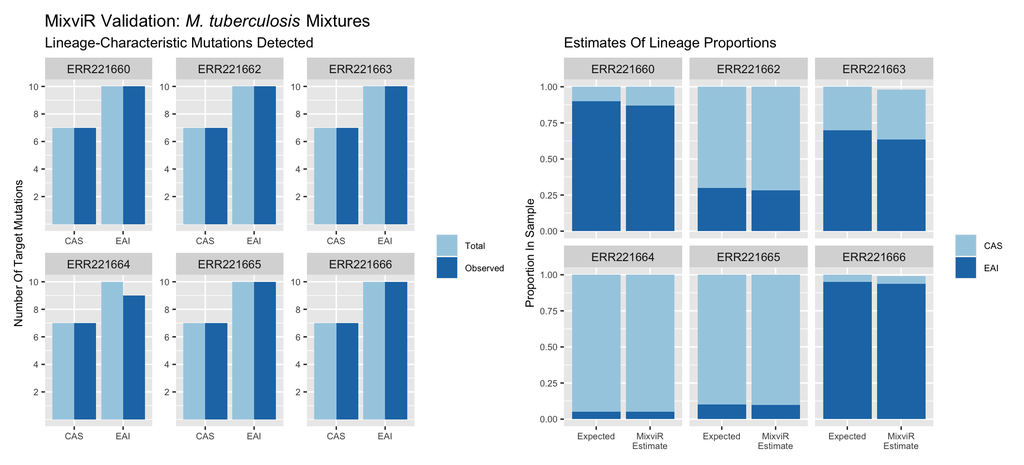

```r
mtub_plot_full <- mtub_mut_count_plot_full + mtub_lin_prop_plot_full
mtub_plot_full
```

```r
ggplot2::ggsave(filename = "../../AEM_revision/Figure_3.tiff", dpi = 300)
```

# Wastewater Example Plots (Fig 4)

## Call Mutations

#note the infiles used here are in csv format instead of vcf #the csv input format is optional for MixviR, but was generally associated with earlier versions, and vcf is recommended for most runs. #running the following code requires downloading the set of csv infiles available at “https://github.com/mikesovic/MixviR/tree/main/mixvir_paper/ww_infiles” and updating the *sample.dir* path in the call_mutations() function below to the directory containing the downloaded files.

```r
ww_exp_muts <- call_mutations(sample.dir = "ww_example/infiles",
               csv.infiles = TRUE,
               name.sep = ".csv",
               reference = "Wuhan")
```

### Lineage Present Plot (Fig 4A)

The code below is extracted and edited from the MixviR code that generates the Shiny dashboard. If running interactively, all of the remaining code in this section (down to the section titled ‘Supplemental Material’) can be replaced with the code in this code block…

```r
explore_mutations(muts.df = ww_exp_muts,
                  dates = "https://raw.githubusercontent.com/mikesovic/MixviR/main/mixvir_paper/ww_example_location_date.csv",
                  lineage.muts = "https://raw.githubusercontent.com/mikesovic/MixviR/main/mutation_files/outbreak_20220217.csv")
```

```r
depth.from.all.muts <- TRUE
use.mean <- TRUE
scale.freqs <- TRUE

samp_data <- ww_exp_muts %>%
      dplyr::select(SAMP_NAME, CHR, POS, GENE, ALT_ID, AF, DP)

#merge in dates
dates_df <- readr::read_csv("https://raw.githubusercontent.com/mikesovic/MixviR/main/mixvir_paper/ww_example_location_date.csv", col_types = "cci")

samp_data <- dplyr::left_join(x = samp_data, y = dates_df, by = "SAMP_NAME") %>%
      dplyr::mutate("date" = lubridate::mdy(DATE)) %>%
      dplyr::mutate("Location" = as.character(LOCATION)) %>%
      dplyr::select(-DATE, -LOCATION)

lineage_muts <- readr::read_csv("https://raw.githubusercontent.com/mikesovic/MixviR/main/mutation_files/outbreak_20220217.csv",
          col_types = readr::cols_only(Gene = readr::col_character(),
                                       Mutation = readr::col_character(),
                                       Lineage = readr::col_character())) %>%
        tidyr::unite("ALT_ID",
                     Gene, Mutation,
                     sep = "_")

#identify mutations that are shared by more than one lineage
duplicated <- lineage_muts$ALT_ID[duplicated(lineage_muts$ALT_ID)]

#flag mutations that are shared by more than one lineage
lineage_muts <- lineage_muts %>%
  dplyr::mutate("characteristic" = ifelse(!ALT_ID %in% duplicated, "Y", "N"))

samp_data <- samp_data %>%
     dplyr::filter(Location == "Site 1")

#create master df that will store data for all selected lineages/variants
all_summary <- data.frame()

Lineages <- c("Alpha", "Delta", "Omicron_BA.1")
for (i in 1:length(Lineages)){  #loop over each selected lineage
  #get the mutations characteristic of the current lineage
  muts <- lineage_muts %>%
    dplyr::filter(characteristic == "Y") %>%
    dplyr::filter(Lineage %in% Lineages[[i]]) %>%
    dplyr::pull(ALT_ID)

  #get the number of mutations characteristic of the current lineage
  lineage_n <- length(muts)

#get proportion of characteristic mutations observed on each date for current Location
summary <- samp_data %>%
      #remove any duplicated mutations, keeping one with highest read depth, and summarize
      dplyr::group_by(SAMP_NAME, date, ALT_ID) %>%
      dplyr::arrange(desc(DP), .by_group = TRUE) %>%
      dplyr::ungroup() %>%
      dplyr::distinct(SAMP_NAME, date, ALT_ID, .keep_all = TRUE) %>%
      dplyr::group_by(SAMP_NAME, date) %>%
      dplyr::summarise("Proportion Present" = sum(ALT_ID[AF > 0 & DP >= 0] %in% muts)/lineage_n,
                "Lineage" = paste0(Lineages[[i]], ""),
                "Total Lineage-Characteristic Muts" = lineage_n,
                "Mean_Coverage_All" = mean(DP[DP >= 0], na.rm = TRUE),
                "DP_n_all" = sum(!is.na(DP[DP >= 0])),
                "PropHighDepth" = sum(DP[ALT_ID %in% muts] >= 0)/lineage_n) %>%
      dplyr::ungroup() %>%
      dplyr::mutate("ID" = paste0(SAMP_NAME, "_", date))

#recalculate Mean Coverage based on target mutations only and add in to 'summary' from above
summary2 <- samp_data %>%
  dplyr::filter(ALT_ID %in% muts) %>%
  dplyr::group_by(SAMP_NAME, date, ALT_ID) %>%
  dplyr::arrange(desc(DP), .by_group = TRUE) %>%
  dplyr::ungroup() %>%
  dplyr::distinct(SAMP_NAME, date, ALT_ID, .keep_all = TRUE) %>%
  dplyr::group_by(SAMP_NAME, date) %>%
  dplyr::summarise("Mean Coverage" = mean(DP[DP >= 0]),
                   "DP_n" = sum(!is.na(DP[DP >= 0]))) %>%
  dplyr::ungroup() %>%
  dplyr::mutate("ID" = paste0(SAMP_NAME, "_", date)) %>%
  dplyr::select(ID, `Mean Coverage`, DP_n)

summary <- dplyr::left_join(x = summary, y = summary2, by = "ID")

#add data for current lineage to master df
all_summary <- dplyr::bind_rows(all_summary, summary)

}

#use days since earliest sample date as x axis (lubridate interval)
ints <- lubridate::interval(start = min(all_summary$date), end = all_summary$date)

#convert seconds to days
all_summary <- all_summary %>%
  dplyr::mutate("days" = lubridate::int_length(ints)/86400)

#get vectors for labeling x-axis
break_dates <- unique(all_summary$date)
break_days <- unique(all_summary$days)

#check which type of mean depth to plot
if (depth.from.all.muts == TRUE) {

  #replace Mean Coverage col with data from Mean_Coverage_All
  all_summary <- all_summary %>%
    dplyr::select(-`Mean Coverage`) %>%
    dplyr::rename("Mean Coverage" = "Mean_Coverage_All") %>%
    dplyr::select(-DP_n) %>%
    dplyr::rename("DP_n" = "DP_n_all")
}

#create new column for fill to represent seq depth. Need a constant range for the scale for this to be useful, so capping it at 1000.
all_summary <- all_summary %>%
  dplyr::mutate("mean_cov_scaled" = `Mean Coverage`) %>%
  dplyr::mutate_at(dplyr::vars(mean_cov_scaled), ~replace(., mean_cov_scaled > 1000, 1000)) %>%
  dplyr::mutate("Proportion Present" = round(`Proportion Present`, 3),
                "PropHighDepth" = round(`PropHighDepth`, 3),
                "Mean Coverage" = round(`Mean Coverage`, 3))


#generate plot
pres_plot <- all_summary %>%
    ggplot2::ggplot(ggplot2::aes(x = days,
                                 y = `Proportion Present`)) +
    ggplot2::geom_line(ggplot2::aes(colour = Lineage, group = Lineage), size = 1.5) +
    ggplot2::coord_cartesian(ylim = c(0,1)) +
    ggplot2::theme_classic() +
    ggplot2::scale_color_brewer(palette = "Paired") +
    ggplot2::ggtitle(paste0("Proportion of Lineage-Characteristic Mutations Present: ", "Site 1")) +
    ggplot2::scale_x_continuous(breaks = break_days, labels = break_dates) +
    ggplot2::theme(axis.title.x = ggplot2::element_blank(),
                   axis.text.x = ggplot2::element_text(angle = 45, size = 8, vjust = 0.4),
                   axis.text.y = ggplot2::element_text(size = 8),
                   plot.title = ggplot2::element_text (color = "black", size= 11, face="bold"),
                   axis.title.y = ggplot2::element_blank(),
                   legend.text = ggplot2::element_text(size = 8),
                   legend.title = ggplot2::element_blank(),
                   axis.title = ggplot2::element_text(size = 9)) +
    ggplot2::geom_hline(yintercept = 0.5, color = "red", linetype = 2, alpha = 0.6) +
    ggplot2::geom_point(data = all_summary, mapping = ggplot2::aes(x = days,
                                                                   y = `Proportion Present`,
                                                                   fill = mean_cov_scaled), size = 2.5, stroke = 0, show.legend = FALSE) +
    ggplot2::scale_fill_gradient(low = "#56B1F7",
                                  high = "#132B43",
                                  limits = c(0,1000))

ggplot2::ggsave(filename = "./Figure_4A.tiff", plot = pres_plot, dpi = 300)
```

### Frequency Plot (Fig 4B)

```r
samp_data <- ww_exp_muts %>%
      dplyr::select(SAMP_NAME, CHR, POS, GENE, ALT_ID, AF, DP)

#merge in dates
dates_df <- readr::read_csv("https://raw.githubusercontent.com/mikesovic/MixviR/main/mixvir_paper/ww_example_location_date.csv", col_types = "cci")

samp_data <- dplyr::left_join(x = samp_data, y = dates_df, by = "SAMP_NAME") %>%
      dplyr::mutate("date" = lubridate::mdy(DATE)) %>%
      dplyr::mutate("Location" = as.character(LOCATION)) %>%
      dplyr::select(-DATE, -LOCATION)

lineage_muts <- readr::read_csv("https://raw.githubusercontent.com/mikesovic/MixviR/main/mutation_files/outbreak_20220217.csv",
          col_types = readr::cols_only(Gene = readr::col_character(),
                                       Mutation = readr::col_character(),
                                       Lineage = readr::col_character())) %>%
        tidyr::unite("ALT_ID",
                     Gene, Mutation,
                     sep = "_")

#identify mutations that are shared by more than one lineage
duplicated <- lineage_muts$ALT_ID[duplicated(lineage_muts$ALT_ID)]

#flag mutations that are shared by more than one lineage
lineage_muts <- lineage_muts %>%
  dplyr::mutate("characteristic" = ifelse(!ALT_ID %in% duplicated, "Y", "N"))

samp_data <- samp_data %>%
     dplyr::filter(Location == 'Site 1')

all_summary <- data.frame()

for (i in 1:length(Lineages)){
 muts <- lineage_muts %>%
                dplyr::filter(characteristic == "Y") %>%
                dplyr::filter(Lineage %in% Lineages[[i]]) %>%
                dplyr::select(ALT_ID) %>%
                unlist()

              #get the number of mutations characteristic of the current lineage
              lineage_n <- length(muts)

  summary <- samp_data %>%
                  dplyr::filter(ALT_ID %in% muts) %>%
                  dplyr::group_by(SAMP_NAME, date, ALT_ID) %>%
                  dplyr::arrange(desc(DP), .by_group = TRUE) %>%
                  dplyr::ungroup() %>%
                  dplyr::distinct(SAMP_NAME, date, ALT_ID, .keep_all = TRUE) %>%
                  dplyr::group_by(SAMP_NAME, date) %>%
                  dplyr::summarise("Proportion Present" = length(ALT_ID[AF > 0 & DP >= 0])/lineage_n,
                   "Lineage" = paste0(Lineages[[i]], ""),
                   "Estimated Freq" = mean(AF[AF > 0 & DP >= 0]),
                   "muts_present" = paste0(c(sort(unique(ALT_ID[AF > 0 & DP >= 0]))), collapse = ";"),
                   "muts_absent" = paste0(c(sort(unique(muts[!muts %in% ALT_ID[AF > 0 & DP >= 0]]))), collapse = ";"),
                   "lab1" = "\nMuts Present: ",
                   "lab2" = "\n\nMuts Absent: ") %>%
  dplyr::mutate("muts_list" = glue::glue("{lab1}{muts_present}{lab2}{muts_absent}"),
                "muts_list" = stringr::str_replace_all(string = muts_list, pattern = "NA\n", replacement = ""),
                "muts_list" = gsub('(.{1,30})(;|$)', '\\1;\n', muts_list)) %>%
  dplyr::mutate_at(dplyr::vars(`Estimated Freq`), ~replace(., is.nan(.), 0)) %>%
  dplyr::mutate_at(dplyr::vars(`Estimated Freq`), ~replace(., `Proportion Present` < 0.5, 0))

 #add data for current lineage to master df
 all_summary <- dplyr::bind_rows(all_summary, summary)
}

#use days since earliest sample date as x axis (lubridate interval)
ints <- lubridate::interval(start = min(all_summary$date), end = all_summary$date)

#convert seconds to days
all_summary <- all_summary %>%
  dplyr::mutate("days" = lubridate::int_length(ints)/86400)

#get vectors for labeling x-axis
break_dates <- unique(all_summary$date)
break_days <- unique(all_summary$days)

#generate plot
#only plot bars for lineages defined as "present" in the sample based on chosen proportion threshold

if (scale.freqs == TRUE) {
  all_summary_sum <- all_summary %>%
    dplyr::ungroup() %>%
    dplyr::group_by(date) %>%
    dplyr::summarise("sum" = sum(`Estimated Freq`)) %>%
    dplyr::mutate("over1" = ifelse(sum > 1, "Y", "N"))

  all_summary_sum <- dplyr::left_join(x = all_summary, y = all_summary_sum, by = "date")

  to_scale <- all_summary_sum %>%
    dplyr::filter(over1 == "Y") %>%
    dplyr::group_by(date) %>%
    dplyr::mutate("Estimated Freq" = `Estimated Freq`/sum(`Estimated Freq`))

  unscaled <- all_summary_sum %>%
    dplyr::filter(over1 == "N")

  all_summary <- dplyr::bind_rows(to_scale, unscaled)
}

if (use.mean == TRUE) {
  measure <- "Mean"
} else {
  measure <- "Median"
}

all_summary <- all_summary %>%
  dplyr::mutate("Proportion Present" = round(`Proportion Present`, 3),
                "Estimated Freq" = round(`Estimated Freq`,3))


prop_plot <- all_summary %>%
              dplyr::filter(`Estimated Freq` > 0) %>%
              ggplot2::ggplot(ggplot2::aes(x = days, y = `Estimated Freq`, fill = Lineage)) +
              ggplot2::geom_bar(stat = "identity",
                       position = "stack") +
              ggplot2::theme_classic() +
              ggplot2::scale_fill_brewer(palette = "Paired") +
              ggplot2::ggtitle(paste0("Estimated Frequency of Each Lineage Present: ", "Site 1")) +
              ggplot2::scale_x_continuous(breaks = break_days, labels = break_dates) +
              ggplot2::theme(axis.title.x = ggplot2::element_blank(),
                    axis.text.x = ggplot2::element_text(angle = 45, vjust = 0.4),
                    axis.text = ggplot2::element_text(size = 8),
                    plot.title = ggplot2::element_text (color = "black", size= 11, face="bold"),
                    axis.title.y = ggplot2::element_blank(),
                    legend.text = ggplot2::element_text(size = 8),
                    legend.title = ggplot2::element_blank(),
                    axis.title = ggplot2::element_text(size = 9)) +
              ggplot2::labs(y = paste0("Estimated Frequency (", measure, ")"))

ggplot2::ggsave(filename = "./Figure_4B.tiff", plot = prop_plot, dpi = 300)
```

### Combine Wastewater Plots (Fig 4)

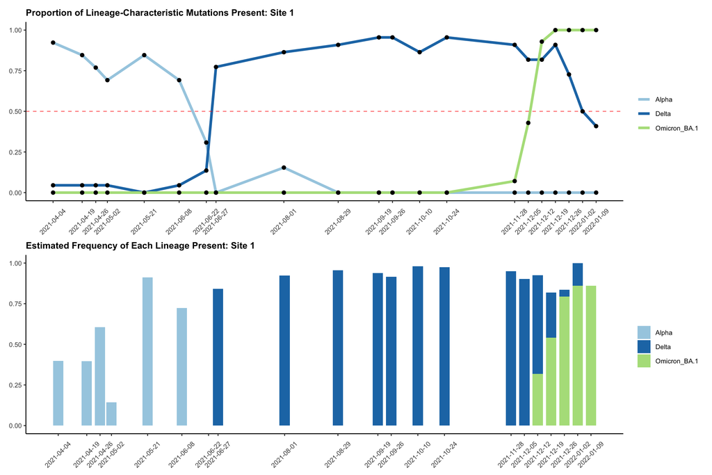

```r
ww_plot <- pres_plot / prop_plot
ww_plot
```

```r
ggplot2::ggsave(filename = "../../AEM_revision/Figure_4.tiff", plot = ww_plot, dpi = 300)
```

# Supplemental Material

Supplemental analyses below.

## Regression Analysis (Fig S1)

### Functions

```r
reg_plot_input <- function(dataset, coverage) {
  if (dataset == "SARS-CoV-2") {
  prop_expected <- readr::read_csv("https://raw.githubusercontent.com/mikesovic/MixviR/main/mixvir_paper/SarsCov2_expected_lineage_proportions.csv")
 } else {
  prop_expected <- readr::read_csv("https://raw.githubusercontent.com/mikesovic/MixviR/main/mixvir_paper/Mtub_expected_lineage_proportions.csv")
}

 prop_expected <- prop_expected %>%
   dplyr::rename("Sample Proportion" = "Scaled Proportion Mean")

 prop_observed <- readr::read_csv(paste0("dragen_runs/", dataset, "/", coverage, "/estimated_proportions.csv"))

 prop_observed <- prop_observed %>%
    dplyr::filter(Proportion_Present >= 0.5)

 prop_observed <- prop_observed %>%
    dplyr::rename("Sample Proportion" = "Mean_Freq") %>%
    dplyr::mutate("Type" = "MixviR Estimate") %>%
    dplyr::select(Sample, Lineage, Type, `Sample Proportion`) %>%
    dplyr::mutate("Sample" = stringr::str_replace_all(Sample, "SRR18936975.hard-filtered.vcf.gz", "Mixture 1")) %>%
    dplyr::mutate("Sample" = stringr::str_replace_all(Sample, "SRR18939817.hard-filtered.vcf.gz", "Mixture 2")) %>%
    dplyr::mutate("Sample" = stringr::str_replace_all(Sample, "SRR18961947.hard-filtered.vcf.gz", "Mixture 3")) %>%
    dplyr::mutate("Sample" = stringr::str_replace_all(Sample, "SRR18961847.hard-filtered.vcf.gz", "Mixture 4")) %>%
    dplyr::mutate("Sample" = stringr::str_replace_all(Sample, "SRR18962157.hard-filtered.vcf.gz", "Mixture 5")) %>%
    dplyr::mutate("Sample" = stringr::str_replace_all(Sample, "SRR18962947.hard-filtered.vcf.gz", "Mixture 6")) %>%
    dplyr::mutate("Sample" = stringr::str_replace_all(Sample, "SRR18962138.hard-filtered.vcf.gz", "Mixture 7")) %>%
    dplyr::mutate("Lineage" = stringr::str_replace_all(Lineage, "Omicron_", "")) %>%
    dplyr::mutate("Lineage" = stringr::str_replace_all(Lineage, "L1 \\(EAI\\)", "EAI")) %>%
    dplyr::mutate("Lineage" = stringr::str_replace_all(Lineage, "L3 \\(CAS\\)", "CAS")) %>%
    dplyr::mutate("Sample" = stringr::str_replace_all(Sample, ".hard-filtered.vcf.gz", ""))

 results_prop <- dplyr::bind_rows(prop_expected, prop_observed)

 results_prop
}
```

## Generate Plots

### SARS-CoV-2

```r
covid_results_prop <- reg_plot_input(dataset = "SARS-CoV-2", coverage = "full")

sars_data <- covid_results_prop %>%
  dplyr::select(Sample, Lineage, Type, `Sample Proportion`) %>%
  tidyr::pivot_wider(names_from = Type, values_from = `Sample Proportion`)

sars_rsquared <- summary(lm(sars_data$`MixviR Estimate`~sars_data$Expected))[[9]]

lab_df <- data.frame("x" = c(0.3, 0.96), "y" = c(0.9, 0.01), "text" = c(paste("r^2 = ", round(sars_rsquared, 3)), "A"))

sars_plot <- sars_data %>% ggplot2::ggplot(ggplot2::aes(x = Expected, y = `MixviR Estimate`, shape = Lineage)) +
  ggplot2::geom_point(size = 2.5) +
  ggplot2::geom_smooth(method = "lm", inherit.aes = FALSE,
                       mapping = ggplot2::aes(x = Expected, y = `MixviR Estimate`), color = "black") +
  ggplot2::theme_classic() +
  ggplot2::labs(title = "MixviR Estimates Of Lineage Frequencies In Mixed Samples",
                subtitle = "SARS-CoV-2",
                x = "Expected Proportion") +
  ggplot2::theme(legend.position = c(0.80, 0.18),
                 legend.key.size = ggplot2::unit(0.5, 'cm'),
                 legend.text = ggplot2::element_text(size = 12),
                 strip.text = ggplot2::element_text(size = 12),
                 axis.text = ggplot2::element_text(size = 11),
                 title = ggplot2::element_text(size = 11),
                 axis.title = ggplot2::element_text(size = 11)) +
  ggplot2::coord_cartesian(ylim = c(0,1)) +
  ggplot2::geom_label(data = lab_df %>% dplyr::slice(1), mapping = ggplot2::aes(x = x, y = y, label = text), inherit.aes = FALSE, size = 5) +
  ggplot2::geom_text(data = lab_df %>% dplyr::slice(2), mapping = ggplot2::aes(x = x, y = y, label = text), inherit.aes = FALSE, size = 6)
```

### M. tuberculosis

```r
mtub_results_prop <- reg_plot_input(dataset = "mtub", coverage = "full")

mtub_data <- mtub_results_prop %>%
  dplyr::select(Sample, Lineage, Type, `Sample Proportion`) %>%
  tidyr::pivot_wider(names_from = Type, values_from = `Sample Proportion`)

mtub_rsquared <- summary(lm(mtub_data$`MixviR Estimate`~mtub_data$Expected))[[9]]

lab_df <- data.frame("x" = c(0.3, 0.967), "y" = c(0.87, 0.05), "text" = c(paste("r^2 = ", round(mtub_rsquared, 3)), "B"))

mtub_plot <- mtub_data %>% ggplot2::ggplot(ggplot2::aes(x = Expected, y = `MixviR Estimate`, shape = Lineage)) +
  ggplot2::geom_point(size = 2.5) +
  ggplot2::geom_smooth(method = "lm", inherit.aes = FALSE,
                       mapping = ggplot2::aes(x = Expected, y = `MixviR Estimate`), color = "black") +
  ggplot2::theme_classic() +
  ggplot2::labs(title = "",
                subtitle = expression(paste(italic("M. tuberculosis"))),
                x = "Expected Proportion",
                y = ggplot2::element_blank()) +
  ggplot2::theme(legend.position = c(0.80, 0.16),
                 legend.key.size = ggplot2::unit(0.5, 'cm'),
                 legend.text = ggplot2::element_text(size = 12),
                 strip.text = ggplot2::element_text(size = 12),
                 axis.text = ggplot2::element_text(size = 11),
                 title = ggplot2::element_text(size = 11),
                 axis.title = ggplot2::element_text(size = 11)) +
  ggplot2::coord_cartesian(xlim = c(0,1)) +
  ggplot2::geom_label(data = lab_df %>% dplyr::slice(1), mapping = ggplot2::aes(x = x, y = y, label = text), inherit.aes = FALSE, size = 5) +
  ggplot2::geom_text(data = lab_df %>% dplyr::slice(2), mapping = ggplot2::aes(x = x, y = y, label = text), inherit.aes = FALSE, size = 6)
```

### Combine Plots

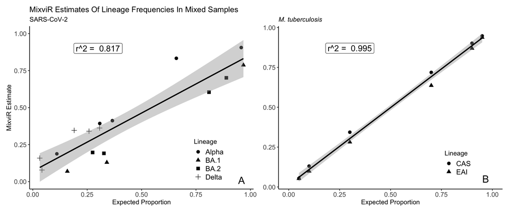

```r
plotS1 <- sars_plot + mtub_plot
plotS1
```

```r
ggplot2::ggsave(file = "../../AEM_revision/Figure_S1.tiff", dpi = 300)
```

# Subsampling Analyses

Two samples from each dataset were selected to evaluate the effect of sequencing coverage on inferences by randomly subsampling reads from each of the corresponding fastq files to achieve depths of approximately 10x, 50x, and 100x, and reanalyzing each according to the methods described for analyses of the full datasets.

## Randomize Fastqs

Fastqs from SRA may be sorted by position, so need to randomize seqs first before subsetting with head. Doing this for two samples from each dataset. Obtained and used “fastq-shuffle.pl” script from https://github.com/chloroExtractorTeam/fastq-shuffle

### SARS-CoV-2

```bash
perl fastq-shuffle.pl -r 3456 -1 covid/fastq/SRR18939817_1.fastq -2 covid/fastq/SRR18939817_2.fastq
perl fastq-shuffle.pl -r 3456 -1 covid/fastq/SRR18961847_1.fastq -2 covid/fastq/SRR18961847_2.fastq
```

### M. tuberculosis

```bash
perl fastq-shuffle.pl -r 3456 -1 mtub/fastq/ERR221662_1.fastq -2 mtub/fastq/ERR221662_2.fastq
perl fastq-shuffle.pl -r 3456 -1 mtub/fastq/ERR221664_1.fastq -2 mtub/fastq/ERR221664_2.fastq
```

## Subsample Fastqs

Here, we randomly subsample two of the the original fastq files from each dataset to approximately 10x, 50x, and 100x coverage and reanalyze to evaluate the effects of the level of coverage on inferences.

### SARS-CoV-2 10X

```bash
head -5980 covid/fastq/SRR18939817_1.fastq.shuffled > covid/10x/fastq/SRR18939817_1.fastq
head -5980 covid/fastq/SRR18961847_2.fastq.shuffled > covid/10x/fastq/SRR18961847_2.fastq
```

### SARS-CoV-2 50X

```bash
head -29900 covid/fastq/SRR18939817_1.fastq.shuffled > covid/50x/fastq/SRR18939817_1.fastq
head -29900 covid/fastq/SRR18961847_2.fastq.shuffled > covid/50x/fastq/SRR18961847_2.fastq
```

### SARS-CoV-2 100X

```bash
head -59804 covid/fastq/SRR18939817_1.fastq.shuffled > covid/100x/fastq/SRR18939817_1.fastq
head -59804 covid/fastq/SRR18961847_2.fastq.shuffled > covid/100x/fastq/SRR18961847_2.fastq
```

### M. tuberculosis 10X

```bash
head -882304 mtub/fastq/ERR221662_1.fastq.shuffled > mtub/10x/fastq/ERR221662_1.fastq
head -882304 mtub/fastq/ERR221664_2.fastq.shuffled > mtub/10x/fastq/ERR221664_2.fastq
```

### M. tuberculosis 50X

```bash
head -4411532 mtub/fastq/ERR221662_1.fastq.shuffled > mtub/50x/fastq/ERR221662_1.fastq
head -4411532 mtub/fastq/ERR221664_2.fastq.shuffled > mtub/50x/fastq/ERR221664_2.fastq
```

### M. tuberculosis 100X

```bash
head -8823064 mtub/fastq/ERR221662_1.fastq.shuffled > mtub/100x/fastq/ERR221662_1.fastq
head -8823064 mtub/fastq/ERR221664_2.fastq.shuffled > mtub/100x/fastq/ERR221664_2.fastq
```

## Analyze Subsampled Datasets

Renamed each of the subsampled fastqs with custom script ‘edit_fq_names.pl’ to get them in proper format for Basespace and uploaded to Basespace. Further analyses followed the workflows described for the full datasets. Specifically, ran the SARS-CoV-2 samples in the Covid Lineage app setting the Virus Primers BED file to V4 Artic and the callability and coverage thresholds to 1. Ran the *M. tuberculosis* samples in the DRAGEN Somatic app with Somatic Hotspots set to “None”, Multi-allelic Filtering disabled, and the vc-enable-unequal-ntd-errors argument set to false. Resulting vcf files were downloaded to revisions/dragen_runs/…

### Plotting Functions

```r
sub_mut_count_plot <- function(dataset, coverage, fig.num) { #coverage should be character vector of 1 or more coverage levels

  all_mut_count_results <- data.frame()

  for (i in coverage) {
    mut_count_total <- readr::read_csv(paste0("dragen_runs/", dataset, "/", i, "/estimated_proportions.csv")) %>%
      dplyr::select(Sample, Lineage, Num_Target_Muts) %>%
      dplyr::mutate("Class" = "Total")

    mut_count_observed <- readr::read_csv(paste0("dragen_runs/", dataset, "/", i, "/estimated_proportions.csv")) %>%
      dplyr::select(Sample, Lineage, Num_Target_Muts, Proportion_Present) %>%
      dplyr::mutate("Class" = "Observed",
                    "Num_Target_Muts" = Num_Target_Muts*Proportion_Present) %>%
      dplyr::select(Sample, Lineage, Num_Target_Muts, Class)

    mut_count_results <- dplyr::bind_rows(mut_count_total, mut_count_observed) %>%
      dplyr::mutate("Sample" = stringr::str_replace_all(Sample, "SRR18939817.+", "Mixture 2")) %>%
      dplyr::mutate("Sample" = stringr::str_replace_all(Sample, "SRR18961847.+", "Mixture 4")) %>%
      dplyr::mutate("Lineage" = stringr::str_replace_all(Lineage, "Omicron_", "")) %>%
      dplyr::mutate("Class" = factor(Class, levels = c("Total", "Observed"))) %>%
      dplyr::mutate("Lineage" = stringr::str_replace_all(Lineage, "L1 \\(EAI\\)", "EAI")) %>%
      dplyr::mutate("Lineage" = stringr::str_replace_all(Lineage, "L3 \\(CAS\\)", "CAS")) %>%
      dplyr::mutate("Sample" = stringr::str_replace_all(Sample, "-.+hard-filtered.vcf.gz", "")) %>%
      dplyr::mutate("Coverage" = i)

    all_mut_count_results <- dplyr::bind_rows(all_mut_count_results, mut_count_results)
  }

  all_mut_count_results <- all_mut_count_results %>%
    mutate("Coverage" = factor(Coverage, levels = c("10x", "50x", "100x")))

  if (dataset == "SARS-CoV-2") {
    all_mut_count_results <- all_mut_count_results %>%
      dplyr::filter((Sample == "Mixture 1" & Lineage %in% c("Alpha", "BA.1")) |
                      (Sample == "Mixture 2" & Lineage %in% c("BA.2", "Delta")) |
                      (Sample == "Mixture 3" & Lineage %in% c("Alpha", "BA.2")) |
                      (Sample == "Mixture 4" & Lineage %in% c("Alpha", "Delta")) |
                      (Sample == "Mixture 5" & Lineage %in% c("Delta", "BA.1")) |
                      (Sample == "Mixture 6" & Lineage %in% c("Alpha", "BA.2", "Delta")) |
                      (Sample == "Mixture 7" & Lineage %in% c("Alpha", "BA.1", "BA.2", "Delta")))
  }


  if (dataset == "SARS-CoV-2") {
    mut_count_plot1 <- ggplot2::ggplot(all_mut_count_results %>% dplyr::filter(Sample == "Mixture 2"), ggplot2::aes(x = Lineage, y = Num_Target_Muts, fill = Class)) +
      ggplot2::geom_bar(stat = "identity", position = "dodge") +
      ggplot2::scale_fill_brewer(palette = "Paired") +
      ggplot2::facet_grid(rows = ggplot2::vars(Sample), cols = ggplot2::vars(Coverage), scales = "free") +
      ggplot2::theme(axis.title.x = ggplot2::element_blank()) +
      ggplot2::labs(y = "Number Of Target Mutations",
                    title = paste0("Effect of Coverage Level: ", dataset, " Mixtures"),
                    subtitle = "Lineage-Characteristic Mutations Detected") +
      ggplot2::theme(legend.direction = "horizontal",
                     legend.position = c(0.82, 1.193),
                     legend.key.size = ggplot2::unit(0.4, 'cm'),
                     legend.title = ggplot2::element_blank(),
                     legend.text = ggplot2::element_text(size = 6),
                     strip.text = ggplot2::element_text(size = 8),
                     axis.text = ggplot2::element_text(size = 6),
                     title = ggplot2::element_text(size = 8),
                     axis.title = ggplot2::element_text(size = 7),
                     plot.subtitle = ggplot2::element_text(size = 6.5, inherit = FALSE))

    mut_count_plot2 <- ggplot2::ggplot(all_mut_count_results %>% dplyr::filter(Sample == "Mixture 4"), ggplot2::aes(x = Lineage, y = Num_Target_Muts, fill = Class)) +
      ggplot2::geom_bar(stat = "identity", position = "dodge") +
      ggplot2::scale_fill_brewer(palette = "Paired") +
      ggplot2::facet_grid(rows = ggplot2::vars(Sample), cols = ggplot2::vars(Coverage), scales = "free") +
      ggplot2::theme(axis.title.x = ggplot2::element_blank()) +
      ggplot2::labs(y = "Number Of Target Mutations") +
      ggplot2::theme(legend.position = "none",
                     strip.text = ggplot2::element_text(size = 8),
                     axis.text = ggplot2::element_text(size = 6),
                     axis.title = ggplot2::element_text(size = 7))

    mut_count_plot <- mut_count_plot1/mut_count_plot2

  } else {

    mut_count_plot1 <- ggplot2::ggplot(all_mut_count_results %>% dplyr::filter(Sample == "ERR221662"), ggplot2::aes(x = Lineage, y = Num_Target_Muts, fill = Class)) +
      ggplot2::geom_bar(stat = "identity", position = "dodge") +
      ggplot2::scale_fill_brewer(palette = "Paired") +
      ggplot2::facet_grid(rows = ggplot2::vars(Sample), cols = ggplot2::vars(Coverage), scales = "free") +
      ggplot2::theme(axis.title.x = ggplot2::element_blank()) +
      #ggplot2::ggtitle("Target Mutations Identified From Mixtures of M. tuberculosis Lineages") +
      ggplot2::labs(y = "Number Of Target Mutations",
                    title = expression(paste("Effect of Coverage Level: ", italic("M. tuberculosis"), " Mixtures")),
                    subtitle = "Lineage-Characteristic Mutations Detected") +
      ggplot2::theme(legend.direction = "horizontal",
                     legend.position = c(0.85, 1.193),
                     legend.key.size = ggplot2::unit(0.4, 'cm'),
                     legend.title = ggplot2::element_blank(),
                     legend.text = ggplot2::element_text(size = 6),
                     strip.text = ggplot2::element_text(size = 8),
                     axis.text = ggplot2::element_text(size = 7),
                     title = ggplot2::element_text(size = 8),
                     axis.title = ggplot2::element_text(size = 7),
                     plot.subtitle = ggplot2::element_text(size=6.5, inherit = FALSE)) +
      scale_y_continuous(breaks = c(2,4,6,8,10), labels = c(2,4,6,8,10))

    mut_count_plot2 <- ggplot2::ggplot(all_mut_count_results %>% dplyr::filter(Sample == "ERR221664"), ggplot2::aes(x = Lineage, y = Num_Target_Muts, fill = Class)) +
      ggplot2::geom_bar(stat = "identity", position = "dodge") +
      ggplot2::scale_fill_brewer(palette = "Paired") +
      ggplot2::facet_grid(rows = ggplot2::vars(Sample), cols = ggplot2::vars(Coverage), scales = "free") +
      ggplot2::theme(axis.title.x = ggplot2::element_blank()) +
      ggplot2::labs(y = "Number Of Target Mutations") +
      ggplot2::theme(legend.position = "none",
                     strip.text = ggplot2::element_text(size = 8),
                     axis.text = ggplot2::element_text(size = 6),
                     axis.title = ggplot2::element_text(size = 7)) +
      scale_y_continuous(breaks = c(2,4,6,8,10), labels = c(2,4,6,8,10))

    mut_count_plot <- mut_count_plot1/mut_count_plot2


  }

  ggplot2::ggsave(filename = paste0("dragen_runs/", dataset, "/", "/Figure_", fig.num, ".tiff"),
                  plot = mut_count_plot,
                  dpi = 300)

  mut_count_plot
}



sub_lin_prop_plot <- function(dataset, coverage, fig.num) {

  all_results_prop <- data.frame()

  if (dataset == "SARS-CoV-2") {
    prop_expected <- readr::read_csv("https://raw.githubusercontent.com/mikesovic/MixviR/main/mixvir_paper/SarsCov2_expected_lineage_proportions.csv")
  } else {
    prop_expected <- readr::read_csv("https://raw.githubusercontent.com/mikesovic/MixviR/main/mixvir_paper/Mtub_expected_lineage_proportions.csv")
  }

  prop_expected <- prop_expected %>%
    dplyr::rename("Sample Proportion" = "Scaled Proportion Mean") %>%
    dplyr::mutate("Coverage" = "Expected")

  for (i in coverage) {
    prop_observed <- readr::read_csv(paste0("dragen_runs/", dataset, "/", i, "/estimated_proportions.csv"))

    prop_observed <- prop_observed %>%
      dplyr::filter(Proportion_Present >= 0.5)

    prop_observed <- prop_observed %>%
      dplyr::rename("Sample Proportion" = "Mean_Freq") %>%
      dplyr::mutate("Type" = "MixviR Estimate") %>%
      dplyr::select(Sample, Lineage, Type, `Sample Proportion`) %>%
      dplyr::mutate("Sample" = stringr::str_replace_all(Sample, "SRR18939817.+", "Mixture 2")) %>%
      dplyr::mutate("Sample" = stringr::str_replace_all(Sample, "SRR18961847.+", "Mixture 4")) %>%
      dplyr::mutate("Lineage" = stringr::str_replace_all(Lineage, "Omicron_", "")) %>%
      dplyr::mutate("Lineage" = stringr::str_replace_all(Lineage, "L1 \\(EAI\\)", "EAI")) %>%
      dplyr::mutate("Lineage" = stringr::str_replace_all(Lineage, "L3 \\(CAS\\)", "CAS")) %>%
      dplyr::mutate("Sample" = stringr::str_replace_all(Sample, "-.+hard-filtered.vcf.gz", "")) %>%
      dplyr::mutate("Coverage" = i)

    all_results_prop <- dplyr::bind_rows(all_results_prop, prop_observed)
  }

  all_results_prop <- dplyr::bind_rows(all_results_prop, prop_expected) %>%
    mutate("Coverage" = factor(Coverage, levels = c("Expected", "10x", "50x", "100x")))

  if (dataset == "SARS-CoV-2") {
    all_results_prop <- all_results_prop %>%
      dplyr::filter((Sample == "Mixture 2" & Lineage %in% c("BA.2", "Delta")) |
                      (Sample == "Mixture 4" & Lineage %in% c("Alpha", "Delta")))
  }

  if (dataset == "mtub") {
    all_results_prop <- all_results_prop %>%
      dplyr::filter(Sample == "ERR221662" | Sample == "ERR221664")
  }

    lin_prop_plot <- ggplot2::ggplot(all_results_prop, ggplot2::aes(x = Coverage, y = `Sample Proportion`, fill = Lineage)) +
      ggplot2::geom_bar(stat = "identity", position = "stack") +
      ggplot2::scale_fill_brewer(palette = "Paired") +
      ggplot2::facet_wrap(ggplot2::vars(Sample), ncol = 1) +
      ggplot2::theme(axis.title.x = ggplot2::element_blank()) +
      ggplot2::labs(y = "Proportion In Sample",
                    title = "",
                    subtitle = "Estimates Of Lineage Proportions") +
      ggplot2::theme(legend.direction = "horizontal",
                     legend.position = c(0.75, 1.088),
                     legend.key.size = ggplot2::unit(0.4, 'cm'),
                     legend.title = ggplot2::element_blank(),
                     legend.text = ggplot2::element_text(size = 6),
                     strip.text = ggplot2::element_text(size = 8),
                     axis.text = ggplot2::element_text(size = 6),
                     title = ggplot2::element_text(size = 8),
                     axis.title = ggplot2::element_text(size = 7),
                     plot.subtitle = ggplot2::element_text(size=6.5, inherit = FALSE)) +
      ggplot2::scale_x_discrete(labels= c("Expected", coverage))

  ggplot2::ggsave(filename = paste0("dragen_runs/", dataset, "/", i, "/Figure_", fig.num, ".tiff"),
                  plot = lin_prop_plot,
                  dpi = 300)

  lin_prop_plot
}
```

## Run `call_mutations()` for each coverage level

### SARS-CoV-2 10x

```r
call_mutations(sample.dir = "dragen_runs/SARS-CoV-2/10x/vcfs/",
                   reference = "Wuhan",
                   write.mut.table = TRUE,
                   outfile.name = "dragen_runs/SARS-CoV-2/10x/covid_samp_mutations.tsv")
```

### SARS-CoV-2 50x

```r
call_mutations(sample.dir = "dragen_runs/SARS-CoV-2/50x/vcfs/",
                   reference = "Wuhan",
                   write.mut.table = TRUE,
                   outfile.name = "dragen_runs/SARS-CoV-2/50x/covid_samp_mutations.tsv")
```

### SARS-CoV-2 100x

```r
call_mutations(sample.dir = "dragen_runs/SARS-CoV-2/100x/vcfs/",
                   reference = "Wuhan",
                   write.mut.table = TRUE,
                   outfile.name = "dragen_runs/SARS-CoV-2/100x/covid_samp_mutations.tsv")
```

### M. tuberculosis 10x

```r
# note this analysis is slow due to the size of the genome - ~5-10 min/sample.
call_mutations(sample.dir = "dragen_runs/mtub/10x/vcfs/",
               fasta.genome = "ref/mtub_clean.fa",
               bed = "ref/mixvir_mtub.bed",
               genetic.code.num = "11",
               write.all.targets = TRUE,
               lineage.muts = "https://raw.githubusercontent.com/mikesovic/MixviR/main/mixvir_paper/Mtub_lineage_muts.csv",
               write.mut.table = TRUE,
               outfile.name = "dragen_runs/mtub/10x/Mtub_samp_mutations.tsv")
```

### M. tuberculosis 50x

```r
# note this analysis is slow due to the size of the genome - ~5-10 min/sample.
call_mutations(sample.dir = "dragen_runs/mtub/50x/vcfs/",
               fasta.genome = "ref/mtub_clean.fa",
               bed = "ref/mixvir_mtub.bed",
               genetic.code.num = "11",
               write.all.targets = TRUE,
               lineage.muts = "https://raw.githubusercontent.com/mikesovic/MixviR/main/mixvir_paper/Mtub_lineage_muts.csv",
               write.mut.table = TRUE,
               outfile.name = "dragen_runs/mtub/50x/Mtub_samp_mutations.tsv")
```

### M. tuberculosis 100x

```r
# note this analysis is slow due to the size of the genome - ~5-10 min/sample.
call_mutations(sample.dir = "dragen_runs/mtub/100x/vcfs/",
               fasta.genome = "ref/mtub_clean.fa",
               bed = "ref/mixvir_mtub.bed",
               genetic.code.num = "11",
               write.all.targets = TRUE,
               lineage.muts = "https://raw.githubusercontent.com/mikesovic/MixviR/main/mixvir_paper/Mtub_lineage_muts.csv",
               write.mut.table = TRUE,
               outfile.name = "dragen_runs/mtub/100x/Mtub_samp_mutations.tsv")
```

## Run `estimate_lineages()` for each coverage level

### SARS-CoV-2 10x

```r
estimate_lineages(read.muts.from = "dragen_runs/SARS-CoV-2/10x/covid_samp_mutations.tsv",
                      lineage.muts = "https://raw.githubusercontent.com/mikesovic/MixviR/main/mutation_files/outbreak_20220217.csv",
                  outfile.name = "dragen_runs/SARS-CoV-2/10x/estimated_proportions.csv",
                  report.all = TRUE)
```

### SARS-CoV-2 50x

```r
estimate_lineages(read.muts.from = "dragen_runs/SARS-CoV-2/50x/covid_samp_mutations.tsv",
                      lineage.muts = "https://raw.githubusercontent.com/mikesovic/MixviR/main/mutation_files/outbreak_20220217.csv",
                  outfile.name = "dragen_runs/SARS-CoV-2/50x/estimated_proportions.csv",
                  report.all = TRUE)
```

### SARS-CoV-2 100x

```r
estimate_lineages(read.muts.from = "dragen_runs/SARS-CoV-2/100x/covid_samp_mutations.tsv",
                      lineage.muts = "https://raw.githubusercontent.com/mikesovic/MixviR/main/mutation_files/outbreak_20220217.csv",
                  outfile.name = "dragen_runs/SARS-CoV-2/100x/estimated_proportions.csv",
                  report.all = TRUE)
```

### M. tuberculosis 10x

```r
estimate_lineages(read.muts.from = "dragen_runs/mtub/10x/Mtub_samp_mutations.tsv",
                  lineage.muts = "https://raw.githubusercontent.com/mikesovic/MixviR/main/mixvir_paper/Mtub_lineage_muts.csv",
                  outfile.name = "dragen_runs/mtub/10x/estimated_proportions.csv",
                  report.all = TRUE)
```

### M. tuberculosis 50x

```r
estimate_lineages(read.muts.from = "dragen_runs/mtub/50x/Mtub_samp_mutations.tsv",
                  lineage.muts = "https://raw.githubusercontent.com/mikesovic/MixviR/main/mixvir_paper/Mtub_lineage_muts.csv",
                  outfile.name = "dragen_runs/mtub/50x/estimated_proportions.csv",
                  report.all = TRUE)
```

### M. tuberculosis 100x

```r
estimate_lineages(read.muts.from = "dragen_runs/mtub/100x/Mtub_samp_mutations.tsv",
                  lineage.muts = "https://raw.githubusercontent.com/mikesovic/MixviR/main/mixvir_paper/Mtub_lineage_muts.csv",
                  outfile.name = "dragen_runs/mtub/100x/estimated_proportions.csv",
                  report.all = TRUE)
```

## Generate Plots For Subsampled Datasets

### SARS-CoV-2

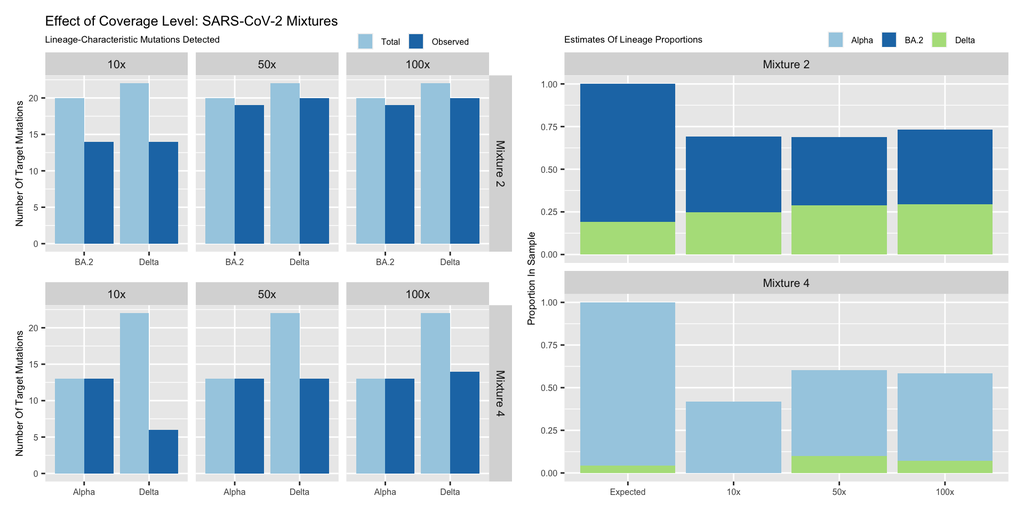

```r
sars_sub_mut_plot <- sub_mut_count_plot(dataset = "SARS-CoV-2", coverage = c("10x", "50x", "100x"), fig.num = "S2A")

sars_sub_lin_plot <- sub_lin_prop_plot(dataset = "SARS-CoV-2", coverage = c("10x", "50x", "100x"), fig.num = "S2B")

sars_sub_plot <- sars_sub_mut_plot | sars_sub_lin_plot

sars_sub_plot
```

```r
ggplot2::ggsave(filename = "../../AEM_revision/Figure_S2.tiff",
                  plot = sars_sub_plot,
                  dpi = 300)
```

### M. tuberculosis

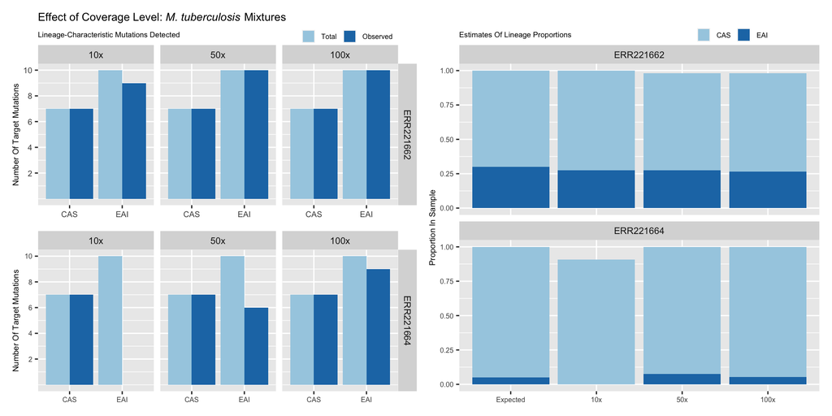

```r
mtub_sub_mut_plot <- sub_mut_count_plot(dataset = "mtub", coverage = c("10x", "50x", "100x"), fig.num = "S3A")

mtub_sub_lin_plot <- sub_lin_prop_plot(dataset = "mtub", coverage = c("10x", "50x", "100x"), fig.num = "S3B")

mtub_sub_plot <- mtub_sub_mut_plot | mtub_sub_lin_plot

mtub_sub_plot
```

```r
ggplot2::ggsave(filename = "../../AEM_revision/Figure_S3.tiff",
                  plot = mtub_sub_plot,
                  dpi = 300)
```

## Shiny Examples (Figs S4-S8)

Examples included were screenshots from tabs in Shiny dashboard.

```r
if (interactive()) {
MixviR::explore_mutations(muts.df = ww_exp_muts,
                          dates = "https://raw.githubusercontent.com/mikesovic/MixviR/main/mixvir_paper/ww_example_location_date.csv",
                  lineage.muts = "https://raw.githubusercontent.com/mikesovic/MixviR/main/mutation_files/outbreak_20220217.csv")
}
```